# Tarea4

Tarea 4 : Integración Numérica Iker Sebastián Bali Elizalde A01656437

1. Desarollo general.

En clase vimos las fórmulas fundamentales para 3 métodos de integración. Al final vimos el planteamiento para las expresiones compuestas. 1. Escribe las expresiones compuestas para los 3 métodos que vimos. Ahorita déjalo indicado para una función arbitraria $f(x)$ en el intervalo $[a,b]$.

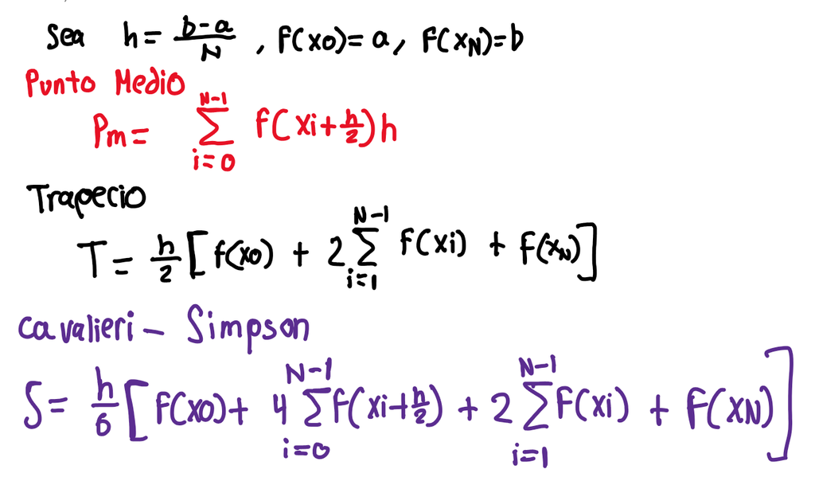

II. Aplicación particular 1

Sea $y=\sin(\pi ln(x))$, $x\geq1$ 1.Encuentra el rango y todas las raíces de la función. Bosquéjala

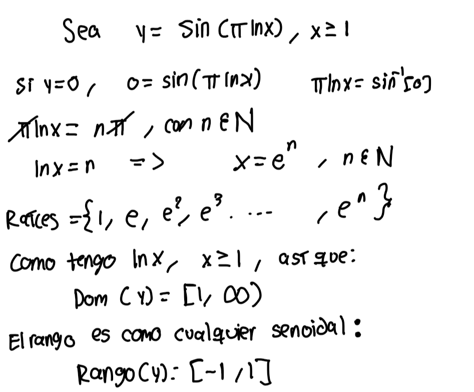

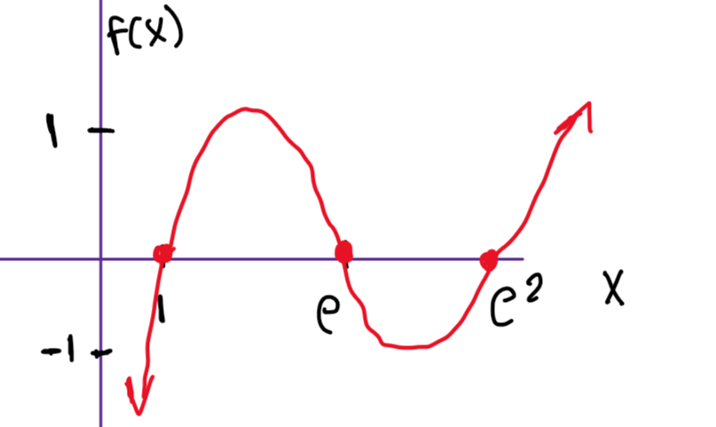

2. Vamos a encontrar la integral definida abarcando a las primeras dos crestas y los primeros dos valles de la función. ¿Cuáles son los límites que vas a usar para esta integral?

Podemos observar mediante la ayuda de Geogebra que las primeras dos crestas y valles están en el siguiente dominio:

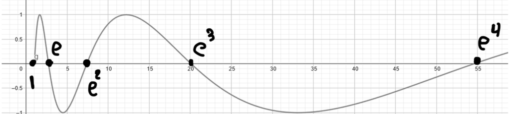

Así que la integral quedaría como:

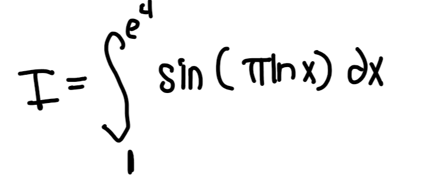

Programa los 3 métodos de integración para este caso. Utiliza el siguiente número de elementos fundamentales: $N=\{1,2,\cdots,999,1000\}$ . Ten cuidado al distinguir entre el número de puntos 'orilla' y de puntos 'centrales'.

```python
# defino funciones

import numpy as np
import matplotlib.pyplot as plt

def f(x):
    y = np.sin(np.pi * np.log(x))
    return y

def punto_medio(a,b,h,f):
    x = np.arange(a,b,h)
    rm = np.sum(f(x+h/2))*h
    return rm

def trapecio(a,b,h,f):
    x = np.arange(a,b+h,h)
    rt = (h/2)*(f(x[0])+2*np.sum(f(x[1:-1]))+f(x[-1]))
    return rt

def simpson(a,b,h,f):
    x = np.arange(a,b+h,h)
    rs = (h/6)*(f(x[0])+4*np.sum(f(x[:-1]+h/2))+2*np.sum(f(x[1:-1]))+f(x[-1]))
    return rs
```

```python
# genero mis pruebas

M = np.zeros([1,1001])
T = np.empty([1,1001])
S = np.empty([1,1001])

for i in range(1,1002):
    h = (np.exp(4) - 1) / i
    M[0,i-1]=punto_medio(1,np.exp(4),h,f)
    T[0,i-1]=trapecio(1,np.exp(4),h,f)
    S[0,i-1]=simpson(1,np.exp(4),h,f)
```

4. Grafica los resultados de la integral como 3 líneas. El eje horizontal es el número de divisiones, el vertical es la integral, y cada línea corresponde a un método. Usa sabiamente la escala de tus ejes.

[figure not shown]

```python
t=np.arange(1,1002,1)
plt.figure(figsize=(10,5))
plt.semilogx(t, M[0], color='b', label='Punto medio')
plt.semilogx(t, T[0], color='g', label='Trapecio')
plt.semilogx(t, S[0], color='r', label='Simpson')
plt.title('Integral númerica de 0 a $e^4$ de  $sin(\pi ln(x))$')
plt.ylabel('Valor aproximado')
plt.xlabel('Número de Rectángulos')
plt.legend()
plt.show()
```

III. Aplicación particular 2. Vamos a calcular numéricamente el valor : $\Gamma(\frac{3}{2})$

1.Escribe la integral correspondiente a esta función

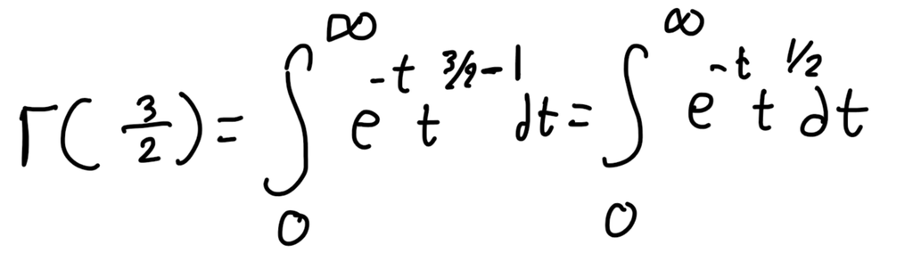

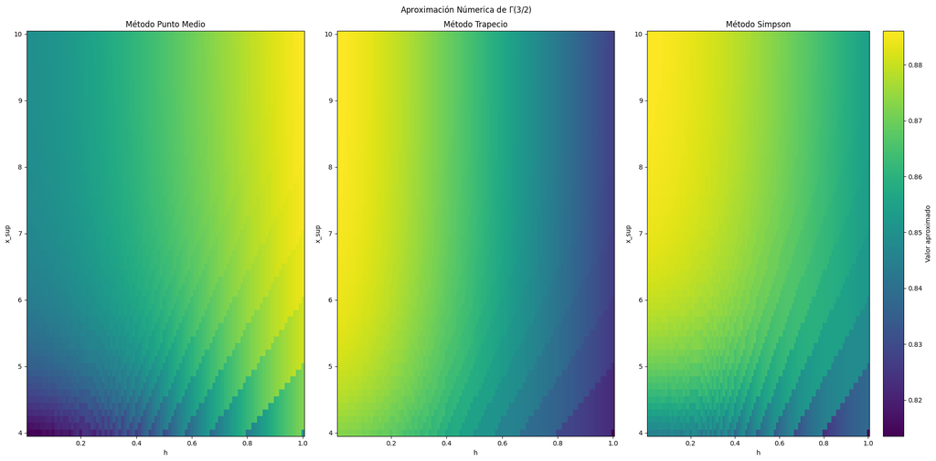

```python
def gamma(x):
    y = (1/np.exp(x))*x**(1/2)
    return y

x_sup = np.arange(4,10.1,0.1)
h = np.arange(0.01,1.01,0.01)

aprox_gamma_medio = np.zeros((len(h), len(x_sup)))
aprox_gamma_trapecio = np.zeros((len(h), len(x_sup)))
aprox_gamma_simpson = np.zeros((len(h), len(x_sup)))

for i, x in enumerate(x_sup):
    for j, hi in enumerate(h):
        aprox_gamma_medio[j, i] = punto_medio(0, x, hi,gamma)
        aprox_gamma_trapecio[j, i] = trapecio(0, x, hi,gamma)
        aprox_gamma_simpson[j, i] = simpson(0, x, hi,gamma)


l=[aprox_gamma_medio.T,aprox_gamma_trapecio.T,aprox_gamma_simpson.T]
m=["Punto Medio","Trapecio","Simpson"]
n=np.arange(1,4,1)
plt.figure(figsize=(20,10))
plt.suptitle("Aproximación Númerica de $\Gamma(3/2)$ ")
for i,j,k in zip(l,n,m):
    plt.subplot(1,3,j)
    p=plt.pcolormesh(h,x_sup,i)
    plt.title(f'Método {k}')
    plt.xlabel('h')
    plt.ylabel('x_sup')
    plt.tight_layout()
plt.colorbar(p, label='Valor aproximado')
plt.show()
```

3. Usemos como referencia la función scipy.special.gamma para encontrar el valor 'exacto'. Calcula el valor absoluto de los errores de las integrales en el paso anterior y despliégalos. Puede que sirva graficar el logaritmos del valor absoluto del error, si es que este varía en órdenes de magnitud. De nuevo, elige el tipo de gráfico que creas adecuado.

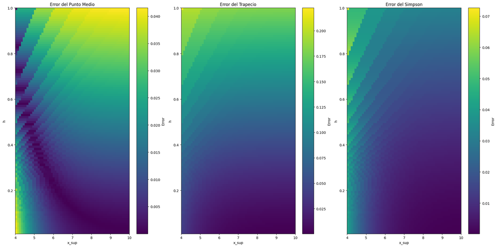

```python
from scipy import special

error_medio = np.zeros((len(h), len(x_sup)))
error_trapecio = np.zeros((len(h), len(x_sup)))
error_simpson = np.zeros((len(h), len(x_sup)))

exacto = special.gamma(3/2)
for i, x in enumerate(x_sup):
    for j, hi in enumerate(h):
        aprox_medio = punto_medio(0, x, hi,gamma)
        aprox_trapecio = trapecio( 0, x, hi,gamma)
        aprox_simpson = simpson( 0, x, hi,gamma)

        error_medio[j, i] = np.abs(exacto - aprox_medio)
        error_trapecio[j, i] = np.abs(exacto - aprox_trapecio)
        error_simpson[j, i] = np.abs(exacto - aprox_simpson)


t=[error_medio,error_trapecio,error_simpson]
m=["Punto Medio","Trapecio","Simpson"]
n=np.arange(1,4,1)

plt.figure(figsize=(20,10))
for i,j,k in zip(t,m,n):
    plt.subplot(1,3,k)
    plt.imshow(i, extent=[4, 10, 0.01, 1], aspect='auto', origin='lower')
    plt.colorbar(label='Error')
    plt.title(f'Error del {j}')
    plt.xlabel('x_sup')
    plt.ylabel('h')
    plt.tight_layout()
plt.show()
```

4. Escojamos el mejor caso, cuando $x_{sup}=10$ . Despliega una figura con dos paneles: en 1 los valores de la integral con diferentes tamaño de rectángulo, y en otra el error (aquí respeta su signo para saber cuando sobre estimas y cuando subestimas la integral).

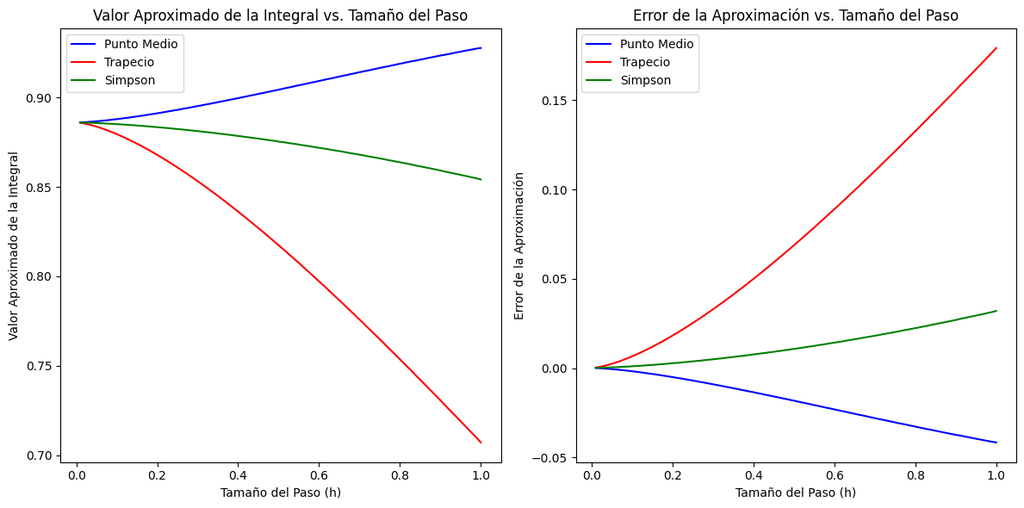

```python
import numpy as np
import matplotlib.pyplot as plt

# Calcula los errores para cada método de integración
error_x_medio = exacto - aprox_gamma_medio[:, 60]
error_x_trapecio = exacto - aprox_gamma_trapecio[:, 60]
error_x_simpson = exacto - aprox_gamma_simpson[:, 60]

# Grafica los resultados
plt.figure(figsize=(12, 6))

plt.subplot(1, 2, 1)
plt.plot(h, aprox_gamma_medio[:, 60], label='Punto Medio', color='blue')
plt.plot(h, aprox_gamma_trapecio[:, 60], label='Trapecio', color='red')
plt.plot(h, aprox_gamma_simpson[:, 60], label='Simpson', color='green')
plt.xlabel('Tamaño del Paso (h)')
plt.ylabel('Valor Aproximado de la Integral')
plt.title('Valor Aproximado de la Integral vs. Tamaño del Paso')
plt.legend()

plt.subplot(1, 2, 2)
plt.plot(h, error_x_medio, label='Punto Medio', color='blue')
plt.plot(h, error_x_trapecio, label='Trapecio', color='red')
plt.plot(h, error_x_simpson, label='Simpson', color='green')
plt.xlabel('Tamaño del Paso (h)')
plt.ylabel('Error de la Aproximación')
plt.title('Error de la Aproximación vs. Tamaño del Paso')
plt.legend()

plt.tight_layout()
plt.show()
```